# assignment

Rebecca Waag

28 4 2023

# Week8: Differential analysis

## Exercise8: Differential analysis

Perform two differential motif accessibility analyses (stress effects and sex effects) on ATAC-seq peak counts in the hippocampus upon stress.

```r
#load packages
suppressPackageStartupMessages({
  library(epiwraps)
  library(AnnotationHub)
  library(motifmatchr)
  library(MotifDb)
  library(universalmotif)
  library(sechm)
  library(BiocParallel)
  library(ggplot2)
  library(chromVAR) #for motif accessibility estimation
  library(SummarizedExperiment) #data structure
  library(limma) #for statistical analysis
  library(stringr) #for word function
})
```

```
## See system.file("LICENSE", package="MotifDb") for use restrictions.
```

```r
#control multithreading with unix
register(MulticoreParam(4))
```

```r
#set working directory
setwd("/mnt/bohacek/rebecca/training/Bioinformatic Approaches Epigenomics/week08")
```

### Load data

Download ATAC-seq peak counts in the hippocampus upon stress (subset of the original data, already in SummarizedExperiment format).

```r
#download data
#download.file("https://ethz-ins.org/content/mouse_mm38_hippocampus.peakCounts.SE.rds", "StressHippo.peakCounts.SE.rds", mode="wb")
HCStress <- readRDS("StressHippo.peakCounts.SE.rds")

#Explore object
#class(HCStress) #RangedSummarizedExperiment
#HCStress #12 samples with 20660 peaks, contains 1 assay
#head(colData(HCStress)) #sequencing depth for each sample is saved in the object
#rowRanges(HCStress) #contains seqnames, ranges and strand information
colnames(HCStress)
```

```
##  [1] "Control_female_GSM6041841.bam" "Control_female_GSM6041842.bam"
##  [3] "Control_female_GSM6041843.bam" "Control_male_GSM6041844.bam"
##  [5] "Control_male_GSM6041845.bam"   "Control_male_GSM6041846.bam"
##  [7] "FSS_female_GSM6041853.bam"     "FSS_female_GSM6041854.bam"
##  [9] "FSS_female_GSM6041855.bam"     "FSS_male_GSM6041856.bam"
## [11] "FSS_male_GSM6041857.bam"       "FSS_male_GSM6041858.bam"
```

```r
#remove ending .bam from colnames
#colnames(HCStress) <- gsub(".bam", "", as.vector(colnames(HCStress))

#extract group from filename and add as metadata
HCStress$group <- word(colnames(HCStress), 1, sep = "_")
HCStress$group
```

```
##  [1] "Control" "Control" "Control" "Control" "Control" "Control" "FSS"
##  [8] "FSS"     "FSS"     "FSS"     "FSS"     "FSS"
```

```r
#extract sex from filename and add as metadata
HCStress$sex<-word(colnames(HCStress), 2, sep = "_")
HCStress$sex
```

```
##  [1] "female" "female" "female" "male"   "male"   "male"   "female" "female"
##  [9] "female" "male"   "male"   "male"
```

```r
#add group and sex manually
#HCStress$group <- c("control", "control", "control", "control", "control", "control", "FSS", "FSS", "FSS", "FSS", "FSS", "FSS")
#HCStress$sex <- c("female", "female", "female", "male", "male", "male", "female", "female", "female", "male", "male", "male")
```

### Load genomic sequence

```r
#load genome sequence GRCm38
ah <- AnnotationHub(localHub = TRUE)
```

```
## snapshotDate(): 2023-04-06
```

```r
mm38 <- ah[["AH68356"]]
```

```
## loading from cache
```

```
## require("rtracklayer")
```

```r
#class(mm38) #2.bit format, does not work with chormVar:addGCBias

#export as fasta format
#Biostrings::writeXStringSet(rtracklayer::import(mm38), "mm38.fa")

#load mm38 fasta file
genome_mm38 <- Rsamtools::FaFile("mm38.fa")
class(genome_mm38) #FaFile
```

```
## [1] "FaFile"
## attr(,"package")
## [1] "Rsamtools"
```

### Add GC bias zu SummarizedExperiment object

```r
#add GC bias to the object
HCStress<-chromVAR::addGCBias(HCStress, genome=genome_mm38)
rowRanges(HCStress) #bias column added
```

```
## GRanges object with 20660 ranges and 1 metadata column:
##           seqnames            ranges strand |      bias
##              <Rle>         <IRanges>  <Rle> | <numeric>
##       [1]        1   3012609-3012858      * |     0.348
##       [2]        1   3094941-3095190      * |     0.424
##       [3]        1   3113634-3113883      * |     0.448
##       [4]        1   3119522-3119771      * |     0.448
##       [5]        1   3119880-3120129      * |     0.432
##       ...      ...               ...    ... .       ...
##   [20656]        Y 90744317-90744566      * |     0.636
##   [20657]        Y 90744689-90744938      * |     0.544
##   [20658]        Y 90761326-90761575      * |     0.640
##   [20659]        Y 90804984-90805233      * |     0.472
##   [20660]        Y 90808700-90808949      * |     0.416
##   -------
##   seqinfo: 30 sequences from an unspecified genome; no seqlengths
```

### Get database of motifs

```r
#which databases exist for Mus musculus
motifs <- query(MotifDb, c("Mmusculus")) #outputs default output
motifs #1427 entries in total from 8 sources
```

```
## MotifDb object of length 1427
## | Created from downloaded public sources: 2013-Aug-30
## | 1427 position frequency matrices from 8 sources:
## |         cisbp_1.02:  132
## |        HOCOMOCOv10:  426
## |        JASPAR_2014:   66
## |        JASPAR_CORE:   47
## |         jaspar2016:  165
## |         jaspar2018:  176
## |          jolma2013:  133
## |           UniPROBE:  282
## | 8 organism/s
## |          Mmusculus: 1411
## | Mmusculus;Rnorvegicus;Hsapiens:    6
## | Mmusculus;Hsapiens:    3
## | Mmusculus;Rnorvegicus:    2
## | Mmusculus;Rnorvegicus;Xlaevis;Stropicalis;Ggallus;Hsapiens;Btaurus;Ocuniculus:    2
## | Mmusculus;Rnorvegicus;Hsapiens;Ocuniculus:    1
## |              other:    2
## Mmusculus-cisbp_1.02-M0082_1.02
## Mmusculus-cisbp_1.02-M0083_1.02
## Mmusculus-cisbp_1.02-M0084_1.02
## Mmusculus-cisbp_1.02-M0085_1.02
## Mmusculus-cisbp_1.02-M0104_1.02
## ...
## Mmusculus-UniPROBE-Zfp740.UP00022
## Mmusculus-UniPROBE-Zic1.UP00102
## Mmusculus-UniPROBE-Zic2.UP00057
## Mmusculus-UniPROBE-Zic3.UP00006
## Mmusculus-UniPROBE-Zscan4.UP00026
```

```r
#obtain HOCOMOCOv10 database of motifs
motifs <- query(MotifDb, c("HOCOMOCOv10", "Mmusculus")) #outputs default output
#motifs #contains 426 entries

#convert motif into PWMatrix format
motifs <- do.call(TFBSTools::PWMatrixList, setNames(
           universalmotif::convert_motifs(motifs, class="TFBSTools-PWMatrix"),
           mcols(motifs)$geneSymbol)) #only keep geneSymbol as name
head(motifs) #correctly named
```

```
## PWMatrixList of length 6
## names(6): AHR AIRE ALX1 ANDR AP2A AP2B
```

### Get occurrence of each motif in each peak

```r
#find which peaks contain which motifs
moi<-motifmatchr::matchMotifs(motifs, subject=HCStress, genome=genome_mm38)
moi #output is a matriux instead of GRanges
```

```
## class: RangedSummarizedExperiment
## dim: 20660 426
## metadata(0):
## assays(1): motifMatches
## rownames: NULL
## rowData names(1): bias
## colnames(426): AHR AIRE ... ZN148 ZN423
## colData names(1): name
```

```r
#length(motifs)
head(assay(moi))
```

```
## 6 x 426 sparse Matrix of class "lgCMatrix"
```

```
##   [[ suppressing 426 column names 'AHR', 'AIRE', 'ALX1' ... ]]
```

[output not shown]

[output cut: 69 more lines]

```r
#as.matrix(head(assay(moi)))
```

### Calculate aggregated motif score per sample

```r
#create aggregated motif score per sample
dev_stress <-chromVAR::computeDeviations(object=HCStress,
                                 annotations=moi,
                                 background_peaks=getBackgroundPeaks(HCStress, niterations=1000))

dev_stress #contains genenames as rownames and 2 assays (deviations and z-scores)
```

```
## class: chromVARDeviations
## dim: 426 12
## metadata(0):
## assays(2): deviations z
## rownames(426): AHR AIRE ... ZN148 ZN423
## rowData names(3): name fractionMatches fractionBackgroundOverlap
## colnames(12): Control_female_GSM6041841.bam
##   Control_female_GSM6041842.bam ... FSS_male_GSM6041857.bam
##   FSS_male_GSM6041858.bam
## colData names(3): depth group sex
```

```r
#variability<-computeVariability(dev) #gives error due to duplicate row.names
#plotVariability(variability)
```

### Normalization

```r
head(assays(dev_stress)$z)
```

```
##      Control_female_GSM6041841.bam Control_female_GSM6041842.bam
## AHR                    -0.49814017                     0.2262201
## AIRE                   -0.02418355                    -0.4455196
## ALX1                    0.57798537                     0.2229584
## ANDR                   -5.91435657                    -2.0740497
## AP2A                    0.30422623                    -1.9239166
## AP2B                    1.98022087                    -0.5309282
##      Control_female_GSM6041843.bam Control_male_GSM6041844.bam
## AHR                      0.4171230                  -0.3228287
## AIRE                    -2.4808718                   1.9896220
## ALX1                    -0.2044207                  -0.3292961
## ANDR                    -1.3588658                  -2.6322837
## AP2A                    -0.3780212                   2.1655164
## AP2B                    -1.1140607                   1.6796112
##      Control_male_GSM6041845.bam Control_male_GSM6041846.bam
## AHR                   0.62750789                 -0.71131474
## AIRE                 -0.03867333                 -0.21367636
## ALX1                  0.48452362                 -1.33718461
## ANDR                 -3.41469871                 -4.50502103
## AP2A                  1.64887536                 -0.02098096
## AP2B                 -1.05796123                  0.54022438
##      FSS_female_GSM6041853.bam FSS_female_GSM6041854.bam
## AHR                  0.8336732                -0.2686972
## AIRE                 1.0103484                 1.3546602
## ALX1                -0.7273914                 0.8257525
## ANDR                 7.2971585                 0.2121403
## AP2A                 1.1944159                -1.7329603
## AP2B                 0.8900158                -0.2671409
##      FSS_female_GSM6041855.bam FSS_male_GSM6041856.bam FSS_male_GSM6041857.bam
## AHR                 -1.3153804              -1.0050369               0.5741456
## AIRE                 0.7719766               1.7808606               1.4848908
## ALX1                 0.1254725               0.7281360              -0.3657235
## ANDR                 5.9639897               4.3923856               5.8687511
## AP2A                 0.3963432               0.6700838               1.0904912
## AP2B                 0.2392077               1.4896596               0.9214118
##      FSS_male_GSM6041858.bam
## AHR              0.004040427
## AIRE             0.250263561
## ALX1            -0.329812989
## ANDR             4.752659111
## AP2A            -0.107061084
## AP2B            -0.546378774
```

```r
#add new assay for normalization
assays(dev_stress)$norm<-scale(assays(dev_stress)$z)
dev_stress #new norm assay added
```

```
## class: chromVARDeviations
## dim: 426 12
## metadata(0):
## assays(3): deviations z norm
## rownames(426): AHR AIRE ... ZN148 ZN423
## rowData names(3): name fractionMatches fractionBackgroundOverlap
## colnames(12): Control_female_GSM6041841.bam
##   Control_female_GSM6041842.bam ... FSS_male_GSM6041857.bam
##   FSS_male_GSM6041858.bam
## colData names(3): depth group sex
```

### Differential motif accessibility analysis: Stress effects?

Here, we exclusively model the effect of stress in the dataset, not taking into account the different sexes used for the experiment.

```r
#use group as factor
dev_stress$group<-factor(dev_stress$group)
dev_stress$group
```

```
##  [1] Control Control Control Control Control Control FSS     FSS     FSS
## [10] FSS     FSS     FSS
## Levels: Control FSS
```

```r
#set control as baseline to model the effect of stress, not necessary here
#dev_stress$group<-relevel(dev_stress$group, ref ="control")

#specify a linear model
mm_group <- model.matrix(~group, data=as.data.frame(colData(dev_stress)))

#fit the model
fit_group <- lmFit(assays(dev_stress)$norm, mm_group)

#calculate the t-statistics
fit_group <- eBayes(fit_group)

#summarize results
res_group <- as.data.frame(topTable(fit_group), coef="group", number=Inf)
```

```
## Removing intercept from test coefficients
```

```r
head(res_group)
```

```
##        ID     logFC    AveExpr        t      P.Value   adj.P.Val         B
## 4    ANDR 4.3474666 0.36280675 6.976336 4.346854e-06 0.001851760  4.252756
## 124   GCR 2.8642462 0.33086685 5.638546 4.637984e-05 0.009878905  2.199666
## 307  PRGR 1.9146754 0.02942858 3.357722 4.293935e-03 0.609738794 -1.888622
## 212  MSX2 1.0743948 0.08475672 2.858828 1.191004e-02 0.995374887 -2.810210
## 258 NR1I3 0.8117121 0.11027504 2.439303 2.755359e-02 0.995374887 -3.556524
## 125   GCR 1.0521565 0.04395071 2.285678 3.717062e-02 0.995374887 -3.818767
```

```r
#subset sign. altered TFs into new object
res_group_DE<-subset(res_group, res_group$adj.P.Val<0.05)
nrow(res_group_DE) #the activity of 2 TFs seems to significantly differ between the sexes
```

```
## [1] 2
```

```r
#subsetting sign. up and downregulated TFs
res_group_DE_up<-subset(res_group_DE, res_group_DE$logFC>0)
nrow(res_group_DE_up) #2 of the motifs are more accessible
```

```
## [1] 2
```

```r
res_group_DE_down<-subset(res_group_DE, res_group_DE$logFC<0)
nrow(res_group_DE_down) #0 of the motifs are less accessible
```

```
## [1] 0
```

```r
#manually remove duplicates
res_group <- res_group[-c(6,7),]

#save TF name from ID as separate TF column
res_group$TF<-res_group$ID
head(res_group$TF)
```

```
## [1] "ANDR"  "GCR"   "PRGR"  "MSX2"  "NR1I3" "HIF1A"
```

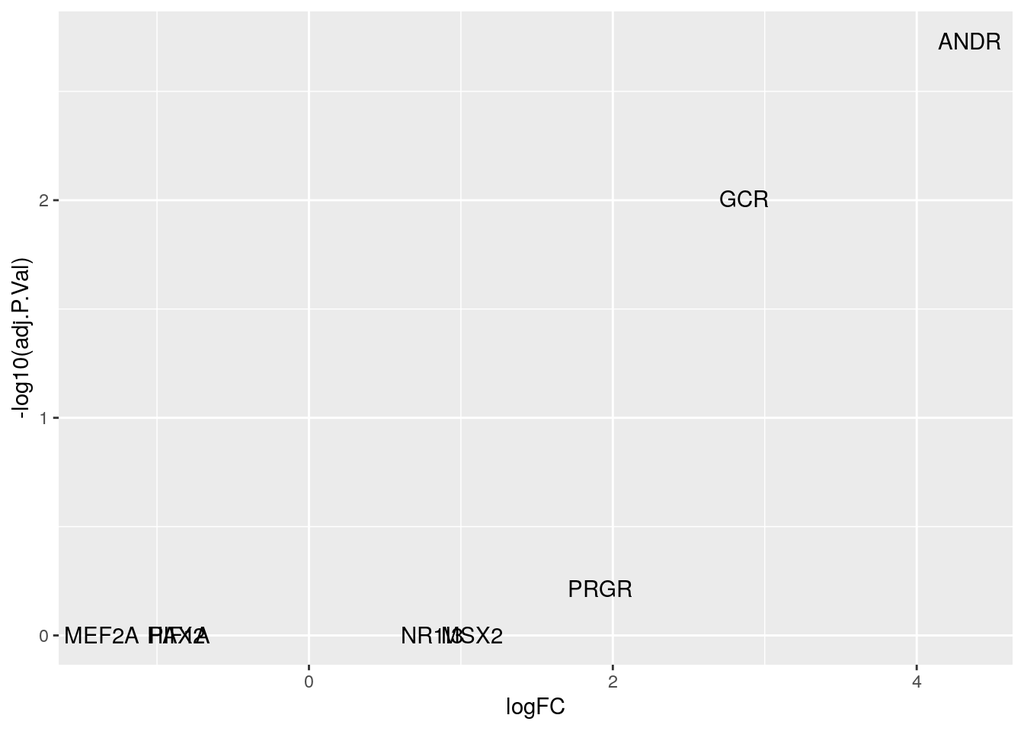

```r
ggplot(res_group, aes(logFC, -log10(adj.P.Val), label=TF))+geom_text()
```

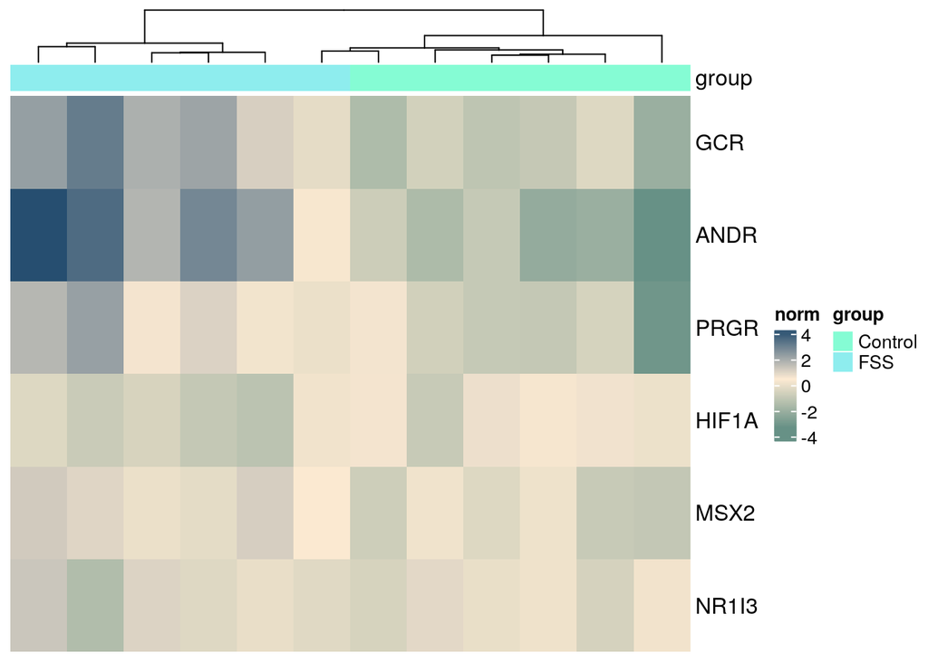

```r
ancols<-list(group=c(control="blue", FSS="black"),
             sex=c(male="green", female="orange"))

#use TF names as row names
res_group <- data.frame(res_group, row.names = res_group[,1])

#use sechm to plot heatmaps of normalized accessibility scores
#sechm(dev_stress, features=head(row.names(res_group)), assayName="norm", cluster_cols=TRUE, hmcols=c("#679186", "#FDEBD3", "#f2624f"))
sechm(dev_stress, features=head(row.names(res_group)), assayName="norm", cluster_cols=TRUE, hmcols=c("#679186", "#FDEBD3", "#264E70"))
```

Differential motif accessibility analysis modeling the effect of stress (not taking sex effects into account) reveals 2 significantly altered accessible motifs between the control and stress group. Of these 2 motifs, 2 are more accessible in the stress group compared to the control group (0 are less accessible).

### Differential motif accessibility analysis: Sex effects?

Here, we exclusively model the effect of sex in the dataset, not taking into account stress effects that might influence the sex effect.

```r
#use sex as factor
dev_stress$sex<-factor(dev_stress$sex)

#set female as baseline to model the effect of stress, not necessary here
#dev_stress$sex<-relevel(dev_stress$sex, ref ="female")

#specify a linear model
mm_sex <- model.matrix(~sex, data=as.data.frame(colData(dev_stress)))

#fit the model
fit_sex <- lmFit(assays(dev_stress)$norm, mm_sex)

#calculate the t-statistics
fit_sex <- eBayes(fit_sex)

#summarize results
res_sex <- as.data.frame(topTable(fit_sex), coef="sex", number=Inf)
```

```
## Removing intercept from test coefficients
```

```r
head(res_sex)
```

```
##        ID     logFC    AveExpr          t      P.Value    adj.P.Val        B
## 403  TYY1 -5.395806 -0.2353041 -10.351874 2.935759e-08 9.685928e-06 9.348604
## 380 TEAD1 -4.311970 -0.1265747 -10.016944 4.547384e-08 9.685928e-06 8.933496
## 330 RUNX3 -2.375191 -0.1455459  -8.166725 6.318216e-07 8.971867e-05 6.396162
## 217   MYB -2.312708 -0.2595566  -6.718527 6.612468e-06 7.042278e-04 4.088211
## 424 ZN143 -2.231504  0.0747685  -5.502001 5.914162e-05 5.038866e-03 1.914824
## 312 PTF1A -1.829052 -0.2079717  -5.024493 1.475365e-04 1.047509e-02 1.006473
```

```r
#subset sign. altered TFs into new object
res_sex_DE<-subset(res_sex, res_sex$adj.P.Val<0.05)
nrow(res_sex_DE) #the activity of 10 TFs seems to significantly differ between the sexesc
```

```
## [1] 10
```

```r
#subsetting sign. up and downregulated TFs
res_sex_DE_up<-subset(res_sex_DE, res_sex_DE$logFC>0)
nrow(res_sex_DE_up) #0 of the motifs are more accessible
```

```
## [1] 0
```

```r
res_sex_DE_down<-subset(res_sex_DE, res_sex_DE$logFC<0)
nrow(res_sex_DE_down) #10 of the motifs are less accessible
```

```
## [1] 10
```

```r
#save TF name from ID as separate TF column
res_sex$TF<-res_sex$ID
head(res_sex$TF)
```

```
## [1] "TYY1"  "TEAD1" "RUNX3" "MYB"   "ZN143" "PTF1A"
```

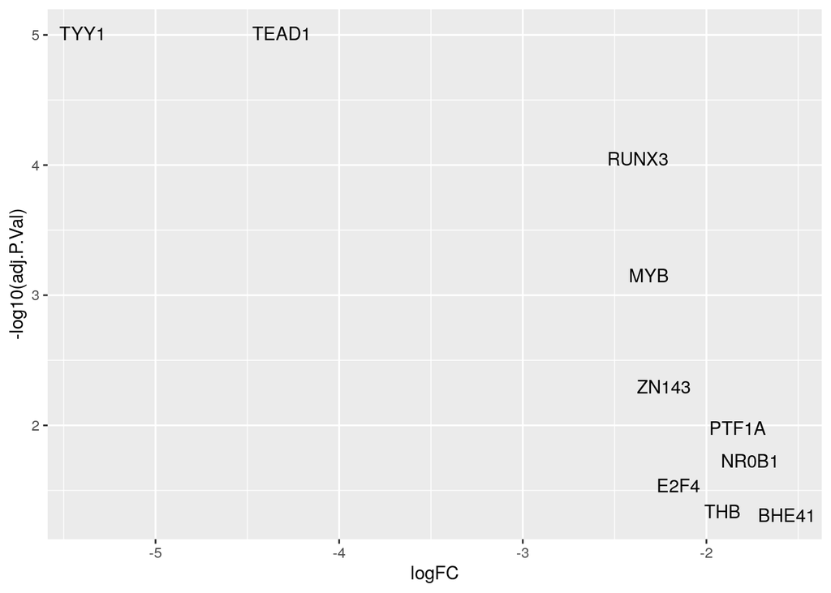

```r
ggplot(res_sex, aes(logFC, -log10(adj.P.Val), label=TF))+geom_text()
```

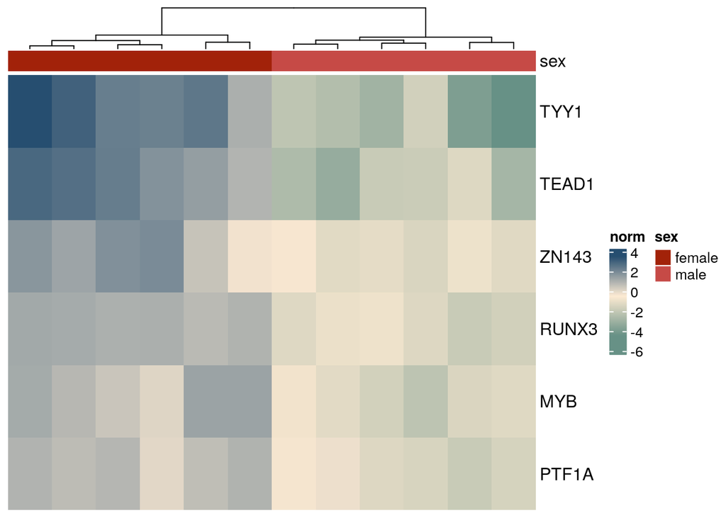

```r
#use TF names as row names
res_sex <- data.frame(res_sex, row.names = res_sex[,1])

#use sechm to plot heatmaps of normalized accessibility scores
res_sex <- data.frame(res_sex, row.names = res_sex[,1])
#sechm(dev_stress, features=head(row.names(res_sex)), assayName="norm", top_annotation=c("sex"), cluster_cols=TRUE, hmcols=c("#679186", "#FDEBD3", "#f2624f"))
sechm(dev_stress, features=head(row.names(res_sex)), assayName="norm", top_annotation=c("sex"), cluster_cols=TRUE, hmcols=c("#679186", "#FDEBD3", "#264E70"))
```

Differential motif accessibility analysis modeling the effect of sex (not taking stress effects into account) reveals 10 significantly altered accessible motifs between males and females. Of these 10 motifs, 10 are less accessible in males compared to females (0 are more accessible).

However, no statement can be made on sex-specific stress effects as this was not modeled here.